# RNA-seq Analysis Report

Marianna Meracdante

2025-09-22

```r
library(rtracklayer)
library(GenomicRanges)
library(DESeq2)
library(sva)
library(ggplot2)
library(VennDiagram)
library(grid)
library(gridExtra)
library(pheatmap)
library(circlize)
library(cluster)
library(mclust)
library(reshape2)
library(plotly)
library(DT)
```

## 0.1 Introduction

This report documents the RNA-seq analysis pipeline, including all code used, outputs, encountered issues, and solutions. The analysis includes:

```r
project_path <- "H:/Drive condivisi/MBC-NeriLab/01_MEMBERS/MARIANNA MERCADANTE/data/"
gtf_path <- file.path(project_path, "Homo_sapiens.GRCh38.114.gtf.gz")

if(!file.exists(gtf_path)){
  stop(paste("File GTF non trovato:", gtf_path))
} else {
  message("File GTF trovato correttamente.")
}

library(rtracklayer)
gtf <- import(gtf_path)


genes <- gtf[gtf$type == "gene"]
mcols(genes)$gene_label <- ifelse(
  mcols(genes)$gene_biotype == "protein_coding",
  paste0(mcols(genes)$gene_id, ":", mcols(genes)$gene_name),
  mcols(genes)$gene_id
)
genes <- genes[!is.na(mcols(genes)$gene_id)]

gene_gr <- GRanges(
  seqnames = seqnames(genes),
  ranges = ranges(genes),
  strand = strand(genes),
  gene_id   = mcols(genes)$gene_id,
  gene_name = mcols(genes)$gene_name,
  gene_label = mcols(genes)$gene_label,
  biotype = mcols(genes)$gene_biotype
)

gene_gr[1:5]
```

```
## GRanges object with 5 ranges and 4 metadata columns:
##       seqnames            ranges strand |         gene_id   gene_name
##          <Rle>         <IRanges>  <Rle> |     <character> <character>
##   [1]        1   3069168-3438621      + | ENSG00000142611      PRDM16
##   [2]        1   5301928-5307394      - | ENSG00000284616        <NA>
##   [3]        1   2403964-2413797      - | ENSG00000157911       PEX10
##   [4]        1   5492978-5494674      + | ENSG00000260972        <NA>
##   [5]        1 10054445-10054781      - | ENSG00000224340    RPL21P21
##                   gene_label              biotype
##                  <character>          <character>
##   [1] ENSG00000142611:PRDM16       protein_coding
##   [2]        ENSG00000284616               lncRNA
##   [3]  ENSG00000157911:PEX10       protein_coding
##   [4]        ENSG00000260972               lncRNA
##   [5]        ENSG00000224340 processed_pseudogene
##   -------
##   seqinfo: 70 sequences from an unspecified genome; no seqlengths
```

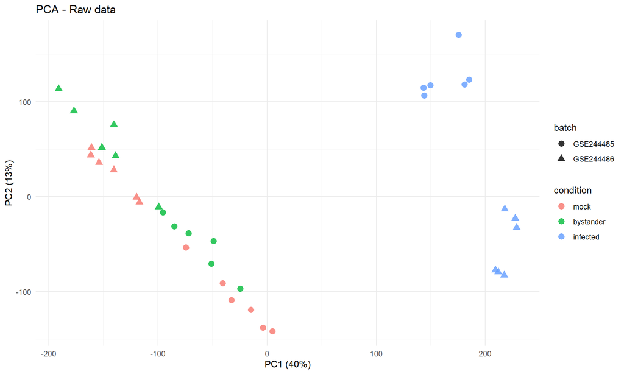

```r
# Percorsi dei file raw counts
file_gse1 <- "H:/Drive condivisi/MBC-NeriLab/01_MEMBERS/MARIANNA MERCADANTE/data/GSE244486_raw_counts.tsv.gz"
file_gse2 <- "H:/Drive condivisi/MBC-NeriLab/01_MEMBERS/MARIANNA MERCADANTE/data/GSE244485_raw_counts.tsv.gz"

# Controlla che i file esistano
if(!file.exists(file_gse1)) stop("File GSE244486_raw_counts.tsv.gz non trovato")
if(!file.exists(file_gse2)) stop("File GSE244485_raw_counts.tsv.gz non trovato")

# Lettura dei raw counts
raw_counts_gse1 <- read.delim(file_gse1, header = TRUE, sep = "\t", row.names = 1)
raw_counts_gse2 <- read.delim(file_gse2, header = TRUE, sep = "\t", row.names = 1)

# Aggiungi prefisso ai nomi delle colonne
colnames(raw_counts_gse1) <- paste0("GSE244486_", colnames(raw_counts_gse1))
colnames(raw_counts_gse2) <- paste0("GSE244485_", colnames(raw_counts_gse2))

# Trova geni comuni
common_genes <- intersect(rownames(raw_counts_gse1), rownames(raw_counts_gse2))
all_raw_counts <- cbind(
  raw_counts_gse1[common_genes, ],
  raw_counts_gse2[common_genes, ]
)
all_raw_counts <- all_raw_counts[rowSums(all_raw_counts) > 0, ]
all_raw_counts <- as.matrix(all_raw_counts)
mode(all_raw_counts) <- "numeric"  # Assicurati che sia numerico

# Info sui campioni
sample_info <- data.frame(
  sample_id = colnames(all_raw_counts),
  condition = rep(c("mock","bystander","infected"), each = 6, times = 2),
  batch = rep(c("GSE244486","GSE244485"), each = 18)
)
rownames(sample_info) <- sample_info$sample_id
sample_info$condition <- relevel(factor(sample_info$condition), ref="mock")
sample_info$batch <- factor(sample_info$batch)


run_pca <- function(count_matrix, sample_info, title_suffix){
  log_data <- log2(count_matrix + 1)
  log_data <- log_data[apply(log_data,1,var) > 0, ]
  log_data <- log_data[, apply(log_data,2,var) > 0]
  log_data <- as.matrix(log_data)
  mode(log_data) <- "numeric"

  # Allinea sample_info
  sample_info <- sample_info[colnames(log_data), ]

  pca <- prcomp(t(log_data), scale.=TRUE)
  variance_explained <- (pca$sdev^2)/sum(pca$sdev^2)

  pca_df <- data.frame(
    PC1 = pca$x[,1],
    PC2 = pca$x[,2],
    batch = sample_info$batch,
    condition = sample_info$condition
  )

  ggplot(pca_df, aes(PC1, PC2, color=condition, shape=batch)) +
    geom_point(size=3, alpha=0.8) +
    labs(
      title = paste("PCA -", title_suffix),
      x = paste0("PC1 (", round(variance_explained[1]*100), "%)"),
      y = paste0("PC2 (", round(variance_explained[2]*100), "%)")
    ) +
    theme_minimal()
}

# Esegui PCA
run_pca(all_raw_counts, sample_info, "Raw data")
```

**Note:**  
- The two datasets are essentially the same; one has viral reads depleted.  
- Batch effect correction was not complete for mock and bystander samples.  
- Raw data were already normalized, affecting expectations on DE analysis.

```r
genes_to_keep <- rowSums(all_raw_counts[,1:18]) > 0 & rowSums(all_raw_counts[,19:36]) > 0
filtered_counts <- all_raw_counts[genes_to_keep, ]
filtered_sample_info <- sample_info[colnames(filtered_counts), ]

combat_corrected_data <- ComBat_seq(filtered_counts,
                                    batch = filtered_sample_info$batch,
                                    group = filtered_sample_info$condition)
```

```
## Found 2 batches
## Using full model in ComBat-seq.
## Adjusting for 2 covariate(s) or covariate level(s)
## Estimating dispersions
## Fitting the GLM model
## Shrinkage off - using GLM estimates for parameters
## Adjusting the data
```

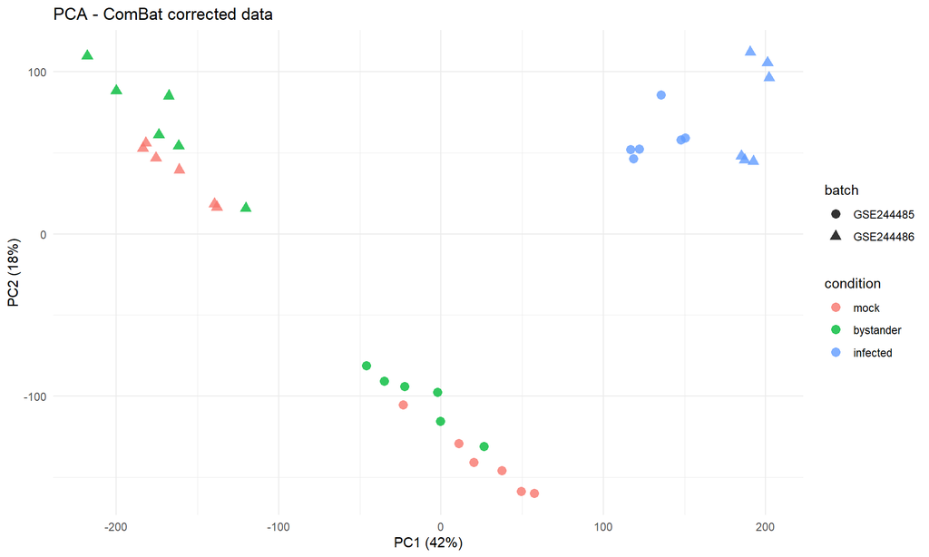

```r
combat_corrected_data <- round(combat_corrected_data)
run_pca(combat_corrected_data, filtered_sample_info, "ComBat corrected data")
```

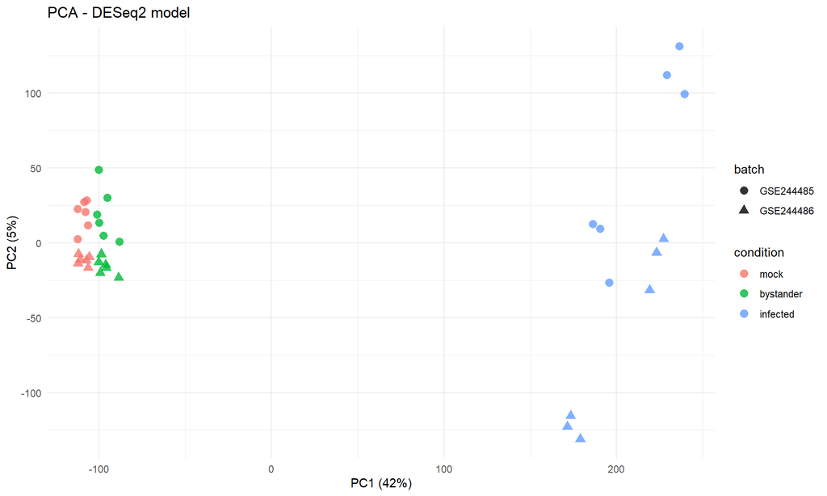

```r
all_raw_counts <- round(all_raw_counts,0)
dds_model <- DESeqDataSetFromMatrix(all_raw_counts, sample_info[,-1], design = ~ batch + condition)
dds_model <- DESeq(dds_model)
vsd_model <- vst(dds_model, blind = FALSE)
vsd_mat <- assay(vsd_model)

run_pca(vsd_mat, sample_info, "DESeq2 model")
```

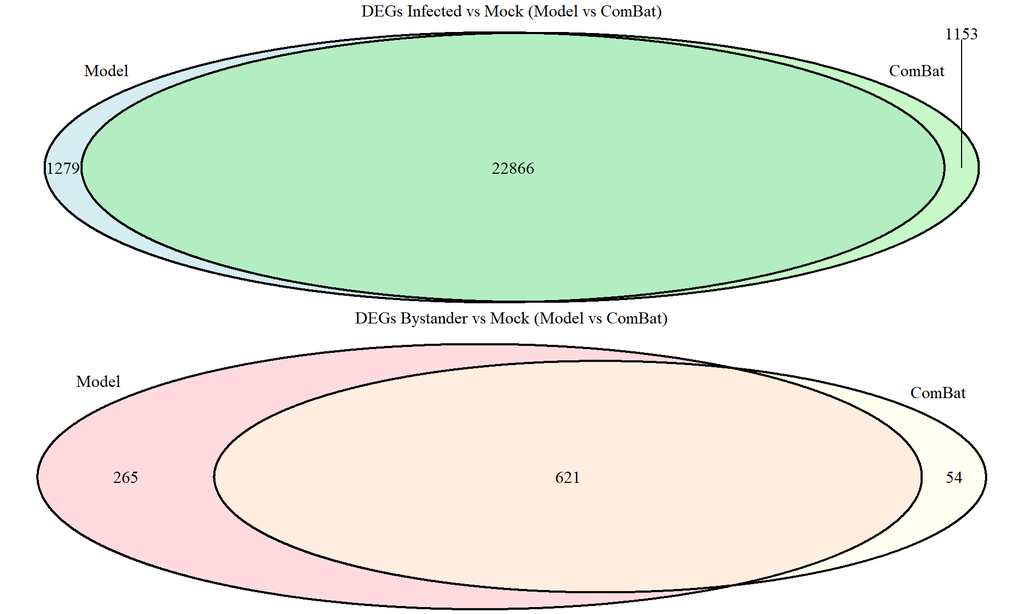

```r
res_infected_model <- results(dds_model, contrast = c("condition", "infected", "mock"))
res_bystander_model <- results(dds_model, contrast = c("condition", "bystander", "mock"))

de_infected_model <- rownames(res_infected_model)[which(res_infected_model$padj < 0.05 & abs(res_infected_model$log2FoldChange) > 1)]
de_bystander_model <- rownames(res_bystander_model)[which(res_bystander_model$padj < 0.05 & abs(res_bystander_model$log2FoldChange) > 1)]

dds_combat <- DESeqDataSetFromMatrix(combat_corrected_data, filtered_sample_info, design = ~ condition)
dds_combat <- DESeq(dds_combat)

res_infected_combat <- results(dds_combat, contrast = c("condition", "infected", "mock"))
res_bystander_combat <- results(dds_combat, contrast = c("condition", "bystander", "mock"))

de_infected_combat <- rownames(res_infected_combat)[which(res_infected_combat$padj < 0.05 & abs(res_infected_combat$log2FoldChange) > 1)]
de_bystander_combat <- rownames(res_bystander_combat)[which(res_bystander_combat$padj < 0.05 & abs(res_bystander_combat$log2FoldChange) > 1)]

# Venn diagram Infected
venn1 <- venn.diagram(
  x = list(Model = de_infected_model, ComBat = de_infected_combat),
  filename = NULL,
  fill = c("lightblue", "lightgreen"),
  main = "DEGs Infected vs Mock (Model vs ComBat)"
)

# Venn diagram Bystander
venn2 <- venn.diagram(
  x = list(Model = de_bystander_model, ComBat = de_bystander_combat),
  filename = NULL,
  fill = c("lightpink", "lightyellow"),
  main = "DEGs Bystander vs Mock (Model vs ComBat)"
)

grid.arrange(grobTree(venn1), grobTree(venn2))
```

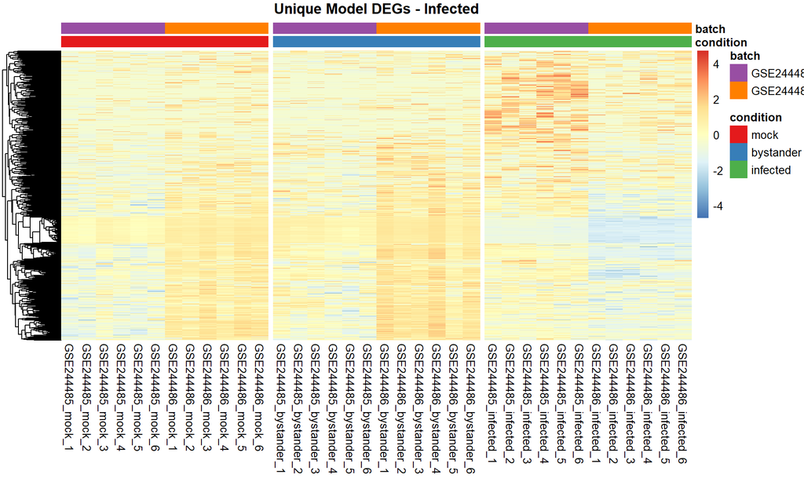

```r
plot_heatmap <- function(gene_list, count_matrix, sample_info, title) {
  if(length(gene_list) > 1){
    mat <- log2(count_matrix[gene_list,,drop=FALSE] + 1)
    rownames(sample_info) <- sample_info$sample_id
    sample_info <- sample_info[colnames(mat),]
    sample_info$condition <- factor(sample_info$condition, levels=c("mock","bystander","infected"))
    sample_info$batch <- factor(sample_info$batch, levels=c("GSE244485","GSE244486"))
    sample_info <- sample_info[order(sample_info$condition,sample_info$batch),]
    mat <- mat[,rownames(sample_info), drop=FALSE]
    cond_tab <- as.integer(table(sample_info$condition))
    gaps_col <- head(cumsum(cond_tab),-1)
    ann_colors <- list(
      condition = c(mock="#E41A1C", bystander="#377EB8", infected="#4DAF4A"),
      batch = c(GSE244485="#984EA3", GSE244486="#FF7F00")
    )
    pheatmap(mat, scale="row", annotation_col=sample_info[,c("condition","batch")], annotation_colors=ann_colors, show_rownames=FALSE, cluster_cols=FALSE, gaps_col=gaps_col, main=title)
  }
}

infected_unique_model <- setdiff(de_infected_model,de_infected_combat)
infected_unique_combat <- setdiff(de_infected_combat,de_infected_model)
bystander_unique_model <- setdiff(de_bystander_model,de_bystander_combat)
bystander_unique_combat <- setdiff(de_bystander_combat,de_bystander_model)

plot_heatmap(infected_unique_model, all_raw_counts, sample_info, "Unique Model DEGs - Infected")
```

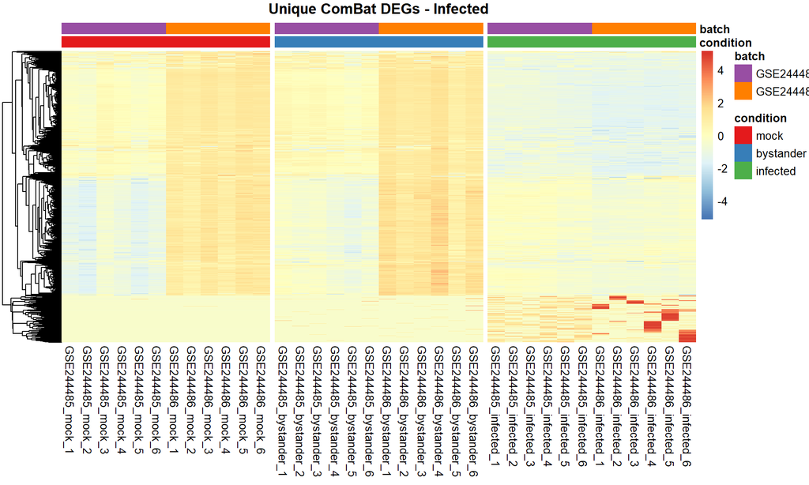

```r
plot_heatmap(infected_unique_combat, combat_corrected_data, filtered_sample_info, "Unique ComBat DEGs - Infected")
```

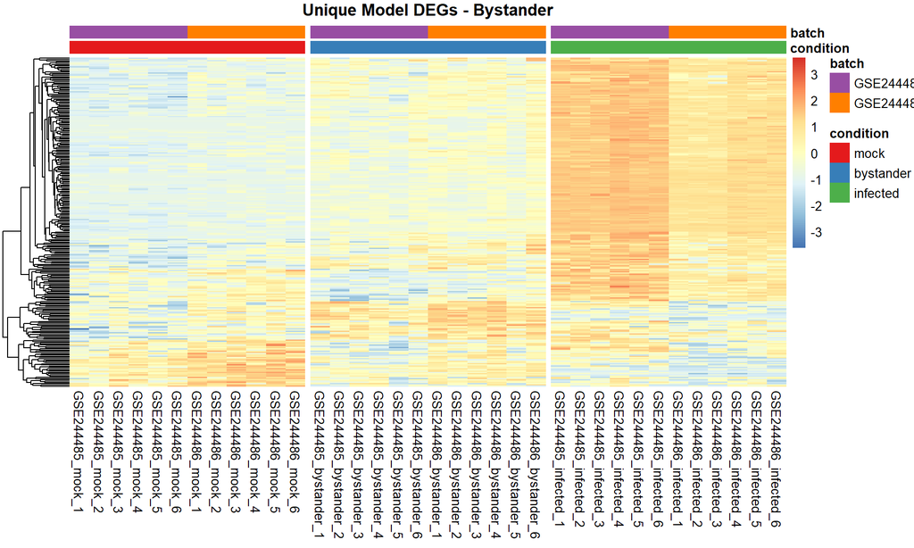

```r
plot_heatmap(bystander_unique_model, all_raw_counts, sample_info, "Unique Model DEGs - Bystander")
```

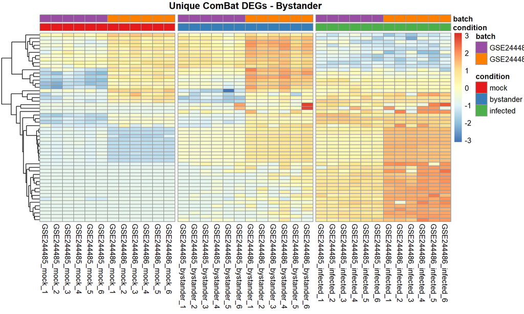

```r
plot_heatmap(bystander_unique_combat, combat_corrected_data, filtered_sample_info, "Unique ComBat DEGs - Bystander")
```

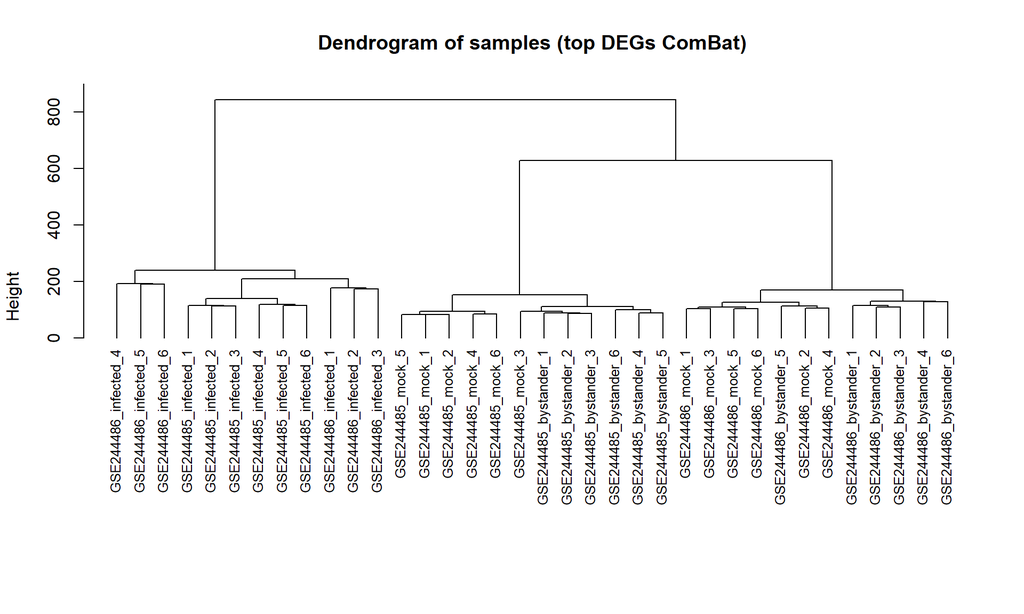

```r
deg_all <- unique(c(de_infected_combat,de_bystander_combat))
log_mat <- log2(combat_corrected_data[deg_all,] + 1)
mat_z <- t(scale(t(log_mat)))
mat_z[is.na(mat_z)] <- 0

# dendrogramma
mat_samples_all <- t(mat_z)
d <- dist(mat_samples_all)
hc <- hclust(d, method="ward.D2")
plot(hc, main="Dendrogram of samples (top DEGs ComBat)", xlab="", sub="", cex=0.8, hang=-1)
```

This dendrogram visualizes the hierarchical clustering of samples. Samples with similar gene expression profiles are grouped together. The height of the branches indicates the degree of similarity, with shorter branches representing more closely related samples.

A key observation from this plot is the clear and strong clustering of the infected samples. They are all grouped together in a single branch, indicating that the infection has a dominant effect on gene expression that successfully overrides any technical or batch-related variation. This suggests that the biological signal for this condition is very robust.

In contrast, the mock and bystander samples are not grouped by their condition. Instead, they are primarily separated by batch, as indicated by the GSE number in their sample names (GSE24485 and GSE24486). This suggests that while the batch correction was successful for the strongly affected “infected” samples, a residual batch effect remains a significant source of variation for the other two conditions, preventing them from clustering cleanly by their biological group.

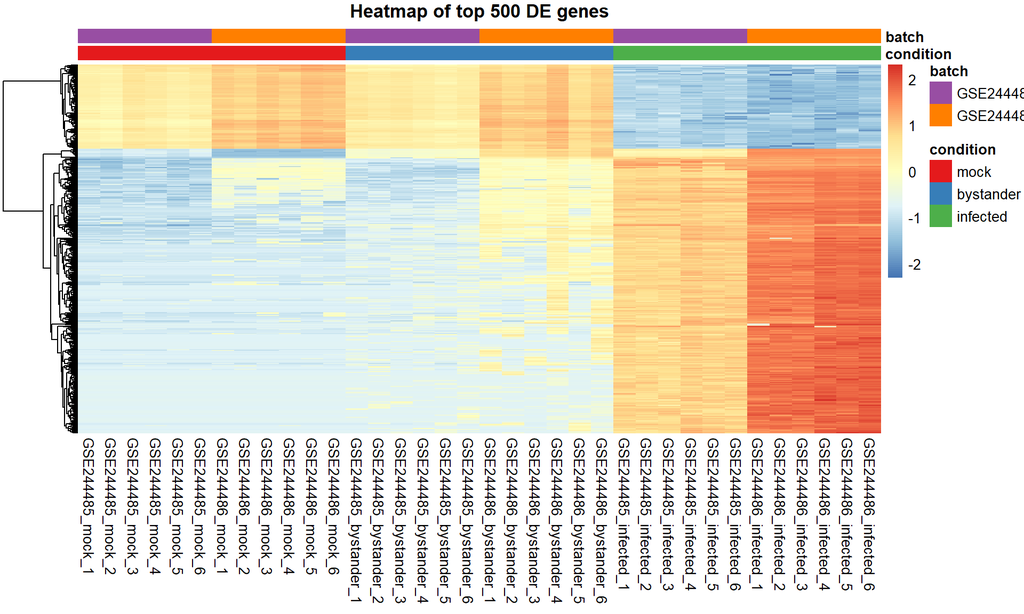

```r
# top 500
gene_var <- apply(log_mat,1,var)
top_genes <- names(sort(gene_var,decreasing=TRUE))[1:500]
mat_z_small <- mat_z[top_genes,]
anno_col <- filtered_sample_info[,c("condition","batch")]
anno_col$condition <- factor(anno_col$condition, levels=c("mock","bystander","infected"))
anno_col$batch <- factor(anno_col$batch, levels=c("GSE244485","GSE244486"))
anno_col <- anno_col[order(anno_col$condition,anno_col$batch),]
mat_heat <- mat_z_small[,rownames(anno_col), drop=FALSE]
ann_colors <- list(condition=c(mock="#E41A1C", bystander="#377EB8", infected="#4DAF4A"),
                   batch=c(GSE244485="#984EA3", GSE244486="#FF7F00"))
pheatmap(mat_heat, scale="row", annotation_col=anno_col, annotation_colors=ann_colors, cluster_rows=TRUE, cluster_cols=FALSE, show_rownames=FALSE, main="Heatmap of top 500 DE genes")
```

The heatmap reveals a very strong and clear separation of samples by condition, which is the most important biological signal. The infected samples form a distinct group with a unique gene expression signature, characterized by a large set of genes that are highly expressed (red) and another set of genes that are lowly expressed (blue) compared to the other conditions. The bystander and mock samples, while showing some subtle differences, have more similar expression profiles to each other, forming a separate major cluster.

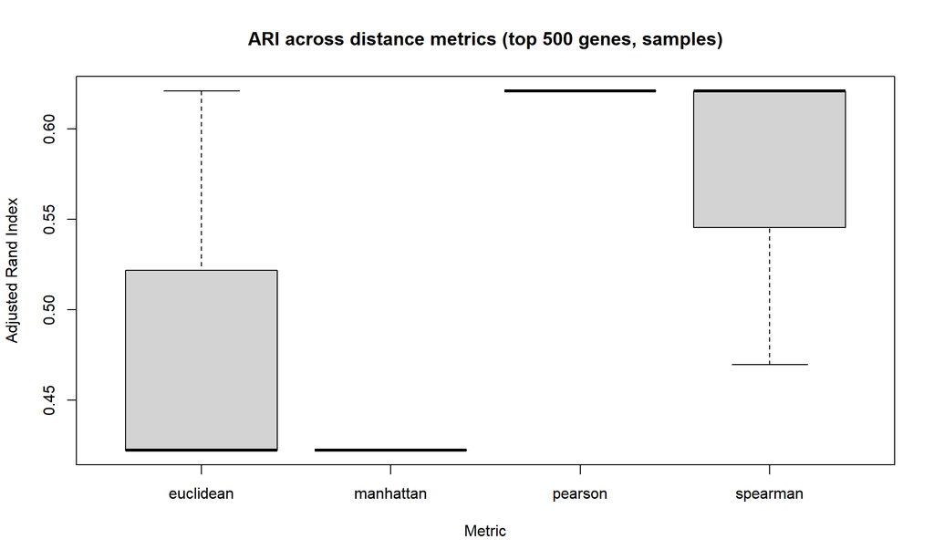

```r
mat_samples <- t(mat_z_small)
common_samples <- intersect(rownames(mat_samples), rownames(filtered_sample_info))
mat_samples <- mat_samples[common_samples, , drop=FALSE]
sample_info_sub <- filtered_sample_info[common_samples, , drop=FALSE]

k <- length(levels(sample_info_sub$condition))
metrics <- c("euclidean","manhattan","pearson","spearman")
linkages <- c("complete","average","ward.D2")
ari_table <- data.frame()

for (m in metrics){
  for (l in linkages){
    if(m %in% c("pearson","spearman")){
      d <- as.dist(1 - cor(t(mat_samples), method=m))
    } else {
      d <- dist(mat_samples, method=m)
    }
    hc <- hclust(d, method=l)
    clusters <- cutree(hc,k)
    cond_vector <- as.integer(factor(sample_info_sub$condition, levels=levels(sample_info_sub$condition)))
    names(cond_vector) <- rownames(sample_info_sub)
    clusters <- clusters[names(cond_vector)]
    ari <- adjustedRandIndex(clusters, cond_vector)
    ari_table <- rbind(ari_table, data.frame(metric=m, linkage=l, ARI=ari))
  }
}

# Boxplot metric
boxplot(ARI~metric, data=ari_table, main="ARI across distance metrics (top 500 genes, samples)", ylab="Adjusted Rand Index", xlab="Metric")
```

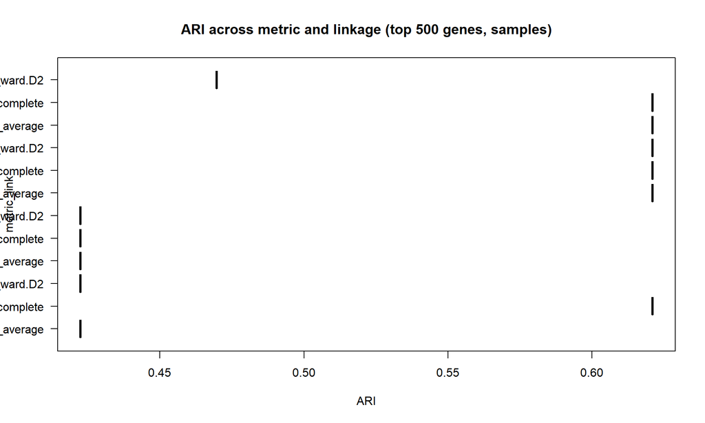

```r
# Boxplot combinato
ari_table$metric_link <- paste(ari_table$metric, ari_table$linkage, sep="_")
boxplot(ARI~metric_link, data=ari_table, horizontal=TRUE, las=1, cex.axis=1, main="ARI across metric and linkage (top 500 genes, samples)")
```

The first boxplot shows the Adjusted Rand Index (ARI) scores for different distance metrics used for sample clustering. The ARI measures the agreement between two data clusterings. In this context, it evaluates how well the unsupervised clustering of samples (based on their gene expression) matches the known biological conditions (infected, mock, bystander). An ARI value closer to 1.0 indicates a perfect agreement, while a value near 0 suggests a random agreement.

Looking at the plot, we can see that the Pearson and Spearman correlation metrics perform significantly better than Euclidean or Manhattan distance. Both Pearson and Spearman metrics have high median ARI values, indicating that they produce sample clusters that strongly align with the true biological conditions. This is expected, as these correlation-based metrics are well-suited for gene expression data, which often exhibits co-regulation and linear relationships.

In contrast, the Euclidean and Manhattan distance metrics perform poorly, yielding much lower ARI scores. These metrics are more sensitive to the magnitude of gene expression changes rather than the pattern or correlation of expression, making them less effective for this type of biological data. This plot confirms that correlation-based metrics are the most appropriate choice for clustering and dimensional reduction in this RNA-seq analysis.

While the second boxplot compares various combinations of distance metrics and linkage methods used for hierarchical clustering.

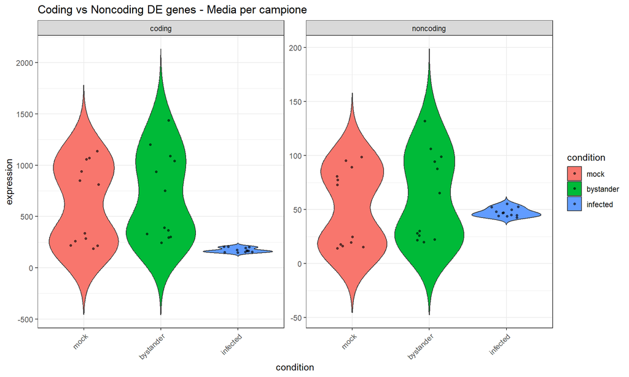

```r
coding_genes <- mcols(gene_gr)$gene_id[mcols(gene_gr)$biotype=="protein_coding"]
noncoding_genes <- mcols(gene_gr)$gene_id[mcols(gene_gr)$biotype!="protein_coding"]

deg_all_clean <- sub("\\..*","",deg_all)
res_coding <- deg_all_clean[deg_all_clean %in% coding_genes]
res_noncoding <- deg_all_clean[deg_all_clean %in% noncoding_genes]

rownames(combat_corrected_data) <- sub("\\..*", "", rownames(combat_corrected_data))
de_coding <- res_coding[res_coding %in% rownames(combat_corrected_data)]
de_noncoding <- res_noncoding[res_noncoding %in% rownames(combat_corrected_data)]

expr_coding <- data.frame(
  sample=colnames(combat_corrected_data),
  condition=filtered_sample_info$condition,
  gene_type="coding",
  expression=as.numeric(colMeans(combat_corrected_data[de_coding,,drop=FALSE]))
)
expr_noncoding <- data.frame(
  sample=colnames(combat_corrected_data),
  condition=filtered_sample_info$condition,
  gene_type="noncoding",
  expression=as.numeric(colMeans(combat_corrected_data[de_noncoding,,drop=FALSE]))
)
expr_mean <- rbind(expr_coding, expr_noncoding)

ggplot(expr_mean, aes(x=condition, y=expression, fill=condition)) +
  geom_violin(trim=FALSE, scale="width") +
  geom_jitter(width=0.2, size=1, alpha=0.6) +
  facet_wrap(~gene_type, scales="free_y") +
  theme_bw() +
  theme(axis.text.x=element_text(angle=45,hjust=1)) +
  ggtitle("Coding vs Noncoding DE genes - Media per campione")
```

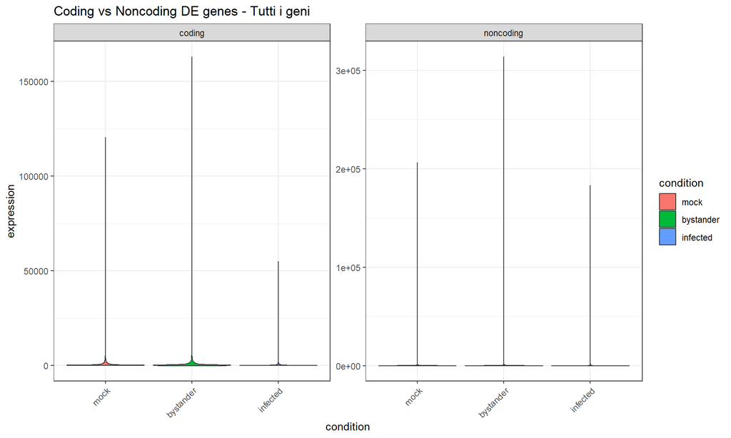

```r
# Violin plot tutti i geni
expr_coding_full <- data.frame(
  sample=rep(colnames(combat_corrected_data), each=length(de_coding)),
  condition=rep(filtered_sample_info$condition, each=length(de_coding)),
  gene_type="coding",
  expression=as.vector(as.matrix(combat_corrected_data[de_coding,,drop=FALSE]))
)
expr_noncoding_full <- data.frame(
  sample=rep(colnames(combat_corrected_data), each=length(de_noncoding)),
  condition=rep(filtered_sample_info$condition, each=length(de_noncoding)),
  gene_type="noncoding",
  expression=as.vector(as.matrix(combat_corrected_data[de_noncoding,,drop=FALSE]))
)
expr_full <- rbind(expr_coding_full, expr_noncoding_full)

ggplot(expr_full, aes(x=condition, y=expression, fill=condition)) +
  geom_violin(trim=FALSE, scale="width") +
  facet_wrap(~gene_type, scales="free_y") +
  theme_bw() +
  theme(axis.text.x=element_text(angle=45,hjust=1)) +
  ggtitle("Coding vs Noncoding DE genes - Tutti i geni")
```

The first violin plot shows the distribution of average expression levels for differentially expressed (DE) coding and noncoding genes across three conditions: mock, bystander, and infected.

Differences in Expression Magnitude: The two panels use different y-axis scales, which is an important detail. The expression values for coding genes (left panel) are significantly higher, ranging from around 0 to over 2000. In contrast, the expression values for noncoding genes (right panel) are much lower, ranging from approximately -50 to 200. This is a common biological observation, as coding genes, which are translated into proteins, are typically more highly expressed than noncoding genes.

Similar Expression in Mock and Bystander: For both coding and noncoding gene types, the mock and bystander samples show similar expression distributions. Their violin plots overlap significantly, suggesting that at the average expression level of DE genes, the bystander effect is not as strong as the direct infection effect.

The violin plot, titled “Coding vs Noncoding DE genes - Tutti i geni” (All genes), shows the distribution of expression for every single differentially expressed (DE) gene, rather than the average per sample. This approach, where you ‘melt’ the data from a wide format to a long format, is often used to visualize the expression of all data points.

However, in this specific case, the plot is not informative because the vast majority of DE genes have very low expression. This causes a phenomenon where the expression values are highly skewed, with a long tail of very few genes having extremely high expression.

This skewed distribution is visually represented by the violin plots appearing as narrow, flat lines near the bottom of the graph, with tall vertical tails extending upwards. The dense clusters of individual data points that are visible in the previous average-expression plot are now compressed into a single, unreadable line. The high-expression genes are visible only as thin vertical lines, making it impossible to discern any meaningful differences between the conditions.

In conclusion, while the ‘melt’ approach is a valid data transformation, it is inappropriate for this specific visualization due to the nature of the data. The highly skewed expression distribution of the top DE genes makes the average-expression plot a much more effective and interpretable way to visualize the differences between conditions.

## 0.2 Conclusions

All code chunks are executable and reproduce the analysis results. Docker-specific instructions are provided in the README.